# R Bootcamp day 2 Simulations and Language Fundamentals

[figure not shown]

[**George G. Vega Yon**](https://ggvy.cl)  
vegayon@usc.edu  
University of Southern California  
Department of Preventive Medicine

August 14th, 2018

# A recap from Day 1

1. We learned about how to get `help()` in R, and about the different resources out there: CRAN Task Views, Package Vigenttes, Stackoverflow, etc..
2. We saw a bit on how to import data in various formats (CSV, SPSS, SAS, etc.) into R with the R packages `readr` and `haven`.
3. We got a glimpse of the functionalities that the R package `dplyr` gives us for data management… the verbs: `filter`, `select`, `arrange`, `mutate`, etc., and the auxiliary function `group_by`

# Today (Day 2)

We will

1. Apply what we learned in day 1 to process some data (we need this for the end)
2. Learn more about the R language fundamentals
3. Do some simulations, in particular, a monte carlo experiment/bootstrap.

# The Dow Jones Industrial Average

- Downloaded from https://quotes.wsj.com/index/DJIA/historical-prices)
- This dataset covers from 1990 to 2018
- It provides the prices at the daily
- We would like to use it to calculate what are the monthly returns and use that later for our simulations.
- Here is the first 10 lines of the CSV

  ```
  Date, Open, High, Low, Close
  07/13/18, 24926.07, 25043.21, 24890.06, 25019.41
  07/12/18, 24802.90, 24939.97, 24802.90, 24924.89
  07/11/18, 24789.48, 24815.16, 24663.82, 24700.45
  07/10/18, 24806.97, 24945.38, 24806.97, 24919.66
  07/09/18, 24519.20, 24796.52, 24518.43, 24776.59
  07/06/18, 24352.47, 24520.29, 24281.47, 24456.48
  07/05/18, 24285.82, 24372.80, 24177.44, 24356.74
  07/03/18, 24359.39, 24444.88, 24150.85, 24174.82
  07/02/18, 24161.53, 24319.42, 24077.56, 24307.18
  ```

# Reading the DOW

As from Day 1, we can use the `readr` package to read this CSV file

```r
# Loading the R package
library(readr)

# Reading the data
dow <- read_csv(
  "HistoricalPrices.csv",
  # We can tell the function how the data is stored
  col_types = cols(Date = col_date(format = "%m/%d/%y"))
  )

dow
```

```
## # A tibble: 7,124 x 5
##    Date         Open   High    Low  Close
##    <date>      <dbl>  <dbl>  <dbl>  <dbl>
##  1 2018-07-13 24926. 25043. 24890. 25019.
##  2 2018-07-12 24803. 24940. 24803. 24925.
##  3 2018-07-11 24789. 24815. 24664. 24700.
##  4 2018-07-10 24807. 24945. 24807. 24920.
##  5 2018-07-09 24519. 24797. 24518. 24777.
##  6 2018-07-06 24352. 24520. 24281. 24456.
##  7 2018-07-05 24286. 24373. 24177. 24357.
##  8 2018-07-03 24359. 24445. 24151. 24175.
##  9 2018-07-02 24162. 24319. 24078. 24307.
## 10 2018-06-29 24324. 24510. 24270. 24271.
## # ... with 7,114 more rows
```

Taking a look at it

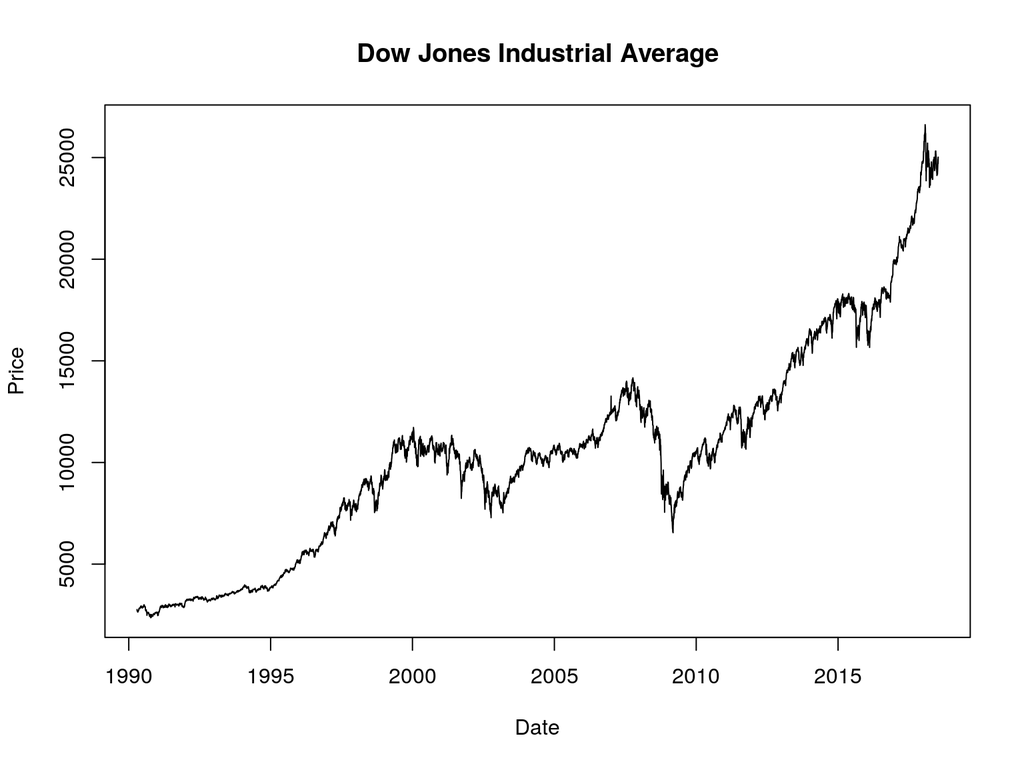

```r
plot(
  x = dow$Date,
  y = dow$Close,
  xlab = "Date",
  ylab = "Price",
  main = "Dow Jones Industrial Average",
  type="l"
  )
```

# Detour: ggplot2

What would be the equivalent using `ggplot2`?

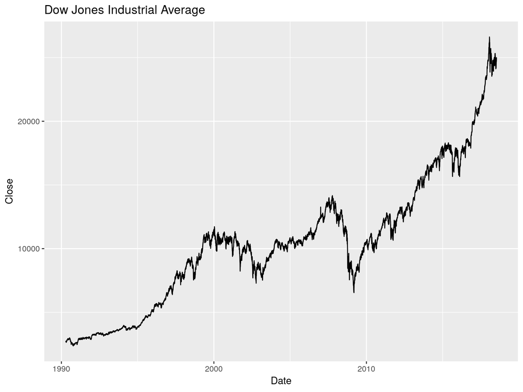

```r
library(ggplot2)
ggplot(dow, aes(x=Date, y=Close)) +
  ggtitle(label = "Dow Jones Industrial Average") +
  geom_line()
```

# Keeping the monthly data only

- Let’s start by loading the R packages (that you already installed)

  ```r
  # Loading the R packages
  library(magrittr)
  library(dplyr)
  ```

# Keeping the monthly data only (cont’d)

- Now, we can use the `%>%` and the dplyr functions to get what we want: A dataset with the **monthly** returns of the DOW:

  ```r
  # Filtering the data
  dow_monthly <- dow %>%           # Passing the dataset
    arrange(Date) %>%              # Sorting by date
    mutate(
      month     = months(Date),    # Extracting month
      month_lag = lag(month)       # Creating a lag of month
    ) %>%
    filter(month != month_lag) %>% # Keeping the last day of the month
    mutate(
      r = Close/lag(Close) - 1     # Computing the monthly return
    )

  dow_monthly
  ```

  ```
  ## # A tibble: 339 x 8
  ##    Date        Open  High   Low Close month     month_lag          r
  ##    <date>     <dbl> <dbl> <dbl> <dbl> <chr>     <chr>          <dbl>
  ##  1 1990-05-01 2669. 2687. 2651. 2669. May       April      NA
  ##  2 1990-06-01 2901. 2920. 2869. 2901. June      May         0.0869
  ##  3 1990-07-02 2899. 2909. 2870. 2899. July      June       -0.000589
  ##  4 1990-08-01 2899. 2931. 2875  2899. August    July        0
  ##  5 1990-09-04 2613. 2618. 2573. 2613. September August     -0.0986
  ##  6 1990-10-01 2516. 2535. 2447. 2516. October   September  -0.0373
  ##  7 1990-11-01 2455. 2473. 2416. 2455. November  October    -0.0242
  ##  8 1990-12-03 2566. 2590. 2544. 2566. December  November    0.0451
  ##  9 1991-01-02 2611. 2652. 2601. 2611. January   December    0.0176
  ## 10 1991-02-01 2731. 2765. 2694. 2731. February  January     0.0460
  ## # ... with 329 more rows
  ```

- We will use this data later on for the simulations part of the presentation.

# R Language Fundamentals: Data types

- The most basic data (object) type in R are vectors.
- Two most common ways to create vectors is using the **combine** function, `c`, and the `vector` function:

  ```
  vector(< mode >, < length >)
  c(< object 1>, < object 2 >, ..., < object n>)
  ```

  For example:

  ```r
  vector("logical", 3)  # This is a logical vector of length 3
  ## [1] FALSE FALSE FALSE
  c(FALSE, TRUE, FALSE) # This is ALSO a logical vector of length 3
  ## [1] FALSE  TRUE FALSE
  ```

- Vectors can be of different modes: `logical`, `integer`, `numeric` (double), `complex`, `character`, and `raw`. (so one mode per vector!).
- Vectors can also be lists, which is a **VERY** special type of object in R (most of its objects are lists!)

  ```r
  vector("list", 2) # This is a list with 2 empty slots
  ## [[1]]
  ## NULL
  ##
  ## [[2]]
  ## NULL
  list(NULL, NULL)  # This is ALSO a list with 2 empty slots
  ## [[1]]
  ## NULL
  ##
  ## [[2]]
  ## NULL
  ```

- Moreover, lists elements can have names

  ```r
  mylist2 <- list(first = NULL, second = 1, third = c("a", "b", "c"))
  mylist2
  ```

  ```
  ## $first
  ## NULL
  ##
  ## $second
  ## [1] 1
  ##
  ## $third
  ## [1] "a" "b" "c"
  ```

  And we can access them as follows

  ```r
  # Getting the 3rd element of the list
  mylist2$third      # By name using the dollar sign
  mylist2[[3]]       # By position
  mylist2[["third"]] # By name using a string
  ```

  ```
  ## [1] "a" "b" "c"
  ```

# R Language Fundamentals: Attributes and Structure

- Objects in R have attributes (metadata)

  ```r
  # Loading the data `diamonds` from ggplot2
  data(diamonds, package = "ggplot2")

  # Here are the attributes of the diamonds dataset
  attributes(diamonds)
  ```

  ```
  ## $class
  ## [1] "tbl_df"     "tbl"        "data.frame"
  ##
  ## $row.names
  ##  [1]  1  2  3  4  5  6  7  8  9 10 11 12 13 14 15 16 17 18 19 20
  ##  [ reached getOption("max.print") -- omitted 53920 entries ]
  ##
  ## $names
  ##  [1] "carat"   "cut"     "color"   "clarity" "depth"   "table"   "price"
  ##  [8] "x"       "y"       "z"
  ```

- You can take a general look at the structure of an R object with the `str()` function

  ```r
  # Let's take a look at the diamonds dataset, again
  str(diamonds)
  ```

  ```
  ## Classes 'tbl_df', 'tbl' and 'data.frame':    53940 obs. of  10 variables:
  ##  $ carat  : num  0.23 0.21 0.23 0.29 0.31 0.24 0.24 0.26 0.22 0.23 ...
  ##  $ cut    : Ord.factor w/ 5 levels "Fair"<"Good"<..: 5 4 2 4 2 3 3 3 1 3 ...
  ##  $ color  : Ord.factor w/ 7 levels "D"<"E"<"F"<"G"<..: 2 2 2 6 7 7 6 5 2 5 ...
  ##  $ clarity: Ord.factor w/ 8 levels "I1"<"SI2"<"SI1"<..: 2 3 5 4 2 6 7 3 4 5 ...
  ##  $ depth  : num  61.5 59.8 56.9 62.4 63.3 62.8 62.3 61.9 65.1 59.4 ...
  ##  $ table  : num  55 61 65 58 58 57 57 55 61 61 ...
  ##  $ price  : int  326 326 327 334 335 336 336 337 337 338 ...
  ##  $ x      : num  3.95 3.89 4.05 4.2 4.34 3.94 3.95 4.07 3.87 4 ...
  ##  $ y      : num  3.98 3.84 4.07 4.23 4.35 3.96 3.98 4.11 3.78 4.05 ...
  ##  $ z      : num  2.43 2.31 2.31 2.63 2.75 2.48 2.47 2.53 2.49 2.39 ...
  ```

# R Language Fundamentals: Missing values

R has different types of Missing values:

- `NA`: no information, has length 1,
- `NULL`: which has length 0,
- `Inf`: Infinite, and
- `NaN`: Not a Number

```r
str(c(NA, 1L))        # Integers can have NAs
##  int [1:2] NA 1
str(c(NaN, 1L, Inf))  # But not NaN or Inf (automatic coercion)
##  num [1:3] NaN 1 Inf
str(c(-Inf, 1, NULL, +Inf)) # And Nulls are... of length 0!
##  num [1:3] -Inf 1 Inf
```

- In the second line, we have an example of *automatic coercion*
- These have companion functions `is.na()`, `is.null`, `is.infinite` (or `is.finite()`, which covers NA, Inf, and NaN), and `is.nan`.

# Questions 1

1. What is the mode of the following vector `myvector <- c(NA, NaN, Inf)`? (try not to use the `mode()` function in R)
2. The `c()` function can be used with other vectors, for example

   ```r
   my_integer_vector <- c(1L, 2L, 3L)
   my_string_vector  <- c("hello", "world")
   ```

   What is the mode of the vector `c(my_integer_vector, my_string_vector)`?
3. What do each one of the functions `is.na`, `is.null`, `is.finite`, `is.infinite`, `is.nan` return on the vector `myvector`?
4. What are the attributes of the following object `mymat <- matrix(runif(12), ncol=4)`?

# Linear Algebra

- **Matrix**: A special class of array, are vectors with a `dim` attribute of length 2 (number of rows and number of columns).

  ```r
  mymat <- matrix(1:9, ncol=3) # A matrix with numbers 1 through 9 with 3 columns
  mymat
  ```

  ```
  ##      [,1] [,2] [,3]
  ## [1,]    1    4    7
  ## [2,]    2    5    8
  ## [3,]    3    6    9
  ```

  ```r
  str(mymat)
  ```

  ```
  ##  int [1:3, 1:3] 1 2 3 4 5 6 7 8 9
  ```

  R stores elements in column major-order. We can access matrices elements in the following way.

  ```r
  mymat[1, 2] # The element in the (1, 2) location of the matrix
  ## [1] 4
  mymat[4]    # The fourth element in the vector... which is (1, 2)
  ## [1] 4
  ```

  Matrices can have row and column names too.
- Some matrix fundamental operators, for matrices `A`, and `B` (both square) with the same dimensions (just for the examples):
  - Element wise product, addition, substraction, and quotient: `A * B`, `A + B`, `A - B`, `A/B`
  - Transpose `t(A)`.
  - Inverse `solve(A)`.
  - Column and row bind, `cbind(A, B)`, `rbind(A, B)`.
  - Matrix product between both `A %*% B`.

# Questions 2

- Given the following matrices `A`, `B`, and C

  ```r
  set.seed(122)
  A <- matrix(rnorm(12), ncol=3)
  B <- matrix(rnorm(12), nrow=3)
  C <- A %*% cbind(1:3) + rnorm(4) # Adding a vector of length 4!
  ```

  Compute
  1. Compute the matrix product between `A` and `B`
  2. Generate the transpose of `A`
  3. Merge `A` and `B` by row and by column.
  4. Calculate the element-wise product of `A` and the transpose of `B`.
  5. Calculate The inverse of the cross product of `A`, this is $(A^\mbox{t}\times A)^{-1}$
  6. Compute $(A^\mbox{t} A)^{-1} A^\mbox{t} C$. How could you do this with a single command in R?

# R Language Fundamentals: Statistical Functions

- R has a very nice set of families of distributions. In general, distribution functions have the following name structure:
  1. **Random Number Generation**: `r[name-of-the-distribution]`, e.g. `rnorm` for normal, `runif` for uniform.
  2. **Density function**: `d[name-of-the-distribution]`, e.g. `dnorm` for normal, `dunif` for uniform.
  3. **Cumulative Distribution Function (CDF)**: `p[name-of-the-distribution]`, e.g. `pnorm` for normal, `punif` for uniform.
  4. **Inverse of the CDF (quantile)**: `q[name-of-the-distribution]`, e.g. `qnorm` for the normal, `qunif` for the uniform.
- In the case of [**pseudo random numbers**](https://en.wikipedia.org/wiki/Pseudorandom_number_generator) (the `r` prefix), it is important to **always** set the seed to ensure **reproducibility**

  ```r
  # First run
  set.seed(12)
  rnorm(4)
  ## [1] -1.4805676  1.5771695 -0.9567445 -0.9200052

  # Second run
  set.seed(12)
  rnorm(4)
  ## [1] -1.4805676  1.5771695 -0.9567445 -0.9200052
  ```

  More distributions available at `??Distributions`.
- Take a look at the normal distribution

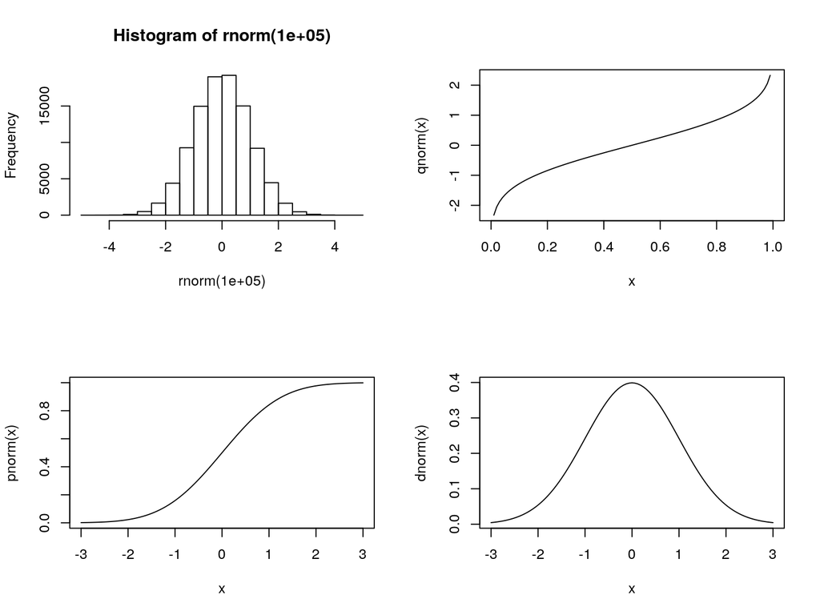

```r
set.seed(12)
op <- par(mfrow = c(2,2))
hist(rnorm(1e5))
curve(qnorm)
curve(pnorm, xlim=c(-3, 3))
curve(dnorm, xlim=c(-3, 3))
```

```r
par(op)
```

- Take a look at the exponential

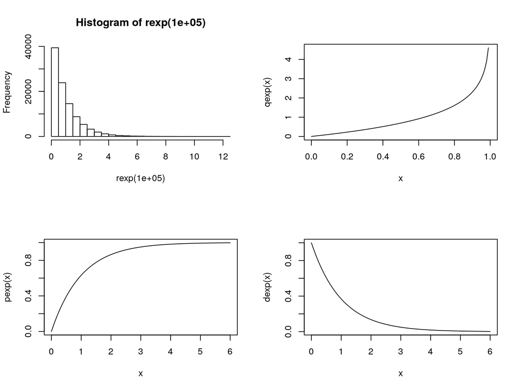

```r
set.seed(12)
op <- par(mfrow = c(2,2))
hist(rexp(1e5))
curve(qexp)
curve(pexp, xlim=c(0, 6))
curve(dexp, xlim=c(0, 6))
```

```r
par(op)
```

# Questions 3

1. Draw 100,000 samples from a chi2 with 2 degrees of freedom (hint: check `?Distributions`).
2. Draw 100,000 samples from a chi2 with 2 degrees of freedom using `rnorm`, to do this, execute the following steps:
   1. Draw 2 standard normal vectors of length 100,000,
   2. Compute the squared version of each vector, now each will be distributed chi2 with 1 degree of freedom,
   3. Sum the 2 vectors, that will be a chi2 with 2 degrees of freedom.
3. To make sure you are getting the (approximately) same solution in both, compute the probability of obtaining values less than 2 using the CDF (cumulative distribution function, a.k.a, probability function) of the chi2 distribution, and compare that value with the following approximation $\frac{1}{n}\sum_i \mathbf{1}(X < 2)$ on the results you obtained in parts 1 and 2.

# Sampling from a vector: The `sample` function

- The `sample` function (part of the base package) provides a way to draw samples and do permutations of vectors.
- For example, if we want to sample 10 numbers (with replacement) from 1 to 5, we can write the following

  ```r
  set.seed(921) # ALWAYS SET THE SEED
  sample(1:5, 10, replace = TRUE)
  ```

  ```
  ##  [1] 5 5 3 1 4 3 2 5 5 2
  ```

- In the case of the `dow_montly` data (without replacement), if we need to sample from `r`, we can write something like this

  ```r
  sample(dow_monthly$r[-1], 10) # Excluding the first element, which is NA
  ```

  ```
  ##  [1]  0.0107319048 -0.0408048544  0.0619830233 -0.0147598268  0.0072516905
  ##  [6]  0.0094119857 -0.0303603194  0.0490905854 -0.0368893101  0.0009049016
  ```

# Questions 4

1. The following code has an error

   ```r
   sample(c(0,1), 10)
   ```

   What can you do to fix it?
2. Run `sample(dow_monthly$r[-1])` twice (so without providing further arguments), what do you get?
3. Suppose that you want to toss 10,000 unfair coins (probability of getting heads is 0.7), How can you use the `sample` function to run such experiment?

# R Language Fundamentals: Functional Programming

- Functions can be a very good companion to your day to day work with R.
- In general terms, R functions are structured as follow:

  ```r
  < name of your function > <- function(
      < argument 1>,
      < argument 2> = < default value >,
      ...,
      < argument n>
  ) {

    < some R code here >

    return(< some result >)

  }
  ```

- For example, if we want to create a function to run the “unfair coin experiment” we could do it in the following way:

  ```r
  # Function definition
  unfair_coin <- function( # The function's name is unfair_coin
    n,                     # It requires the argument `n`
    p = 0.7                # It has a default value for `p`
    ) {

    # Sampling from the coin dist
    ans <- sample(c("H", "T"), n, replace = TRUE, prob = c(p, 1-p))

    # Returning
    ans

  }

  # Testing it
  set.seed(1)
  unfair_coin(20)
  ```

  ```
  ##  [1] "H" "H" "H" "T" "H" "T" "T" "H" "H" "H" "H" "H" "H" "H" "T" "H" "T"
  ## [18] "T" "H" "T"
  ```

# Questions 5

1. Create a function to simulate OLS (ordinary least squares) data with the following:
   - An argument `n`: Number of observations to make
   - An argument `beta`: Coefficient with default value 0.3
   - An argument `alpha`: Coefficient with default value 4
   - `X` and the error are N(0, 1)
   - The function should return both `Y` and `X`

   To generate 100 OLS model observations, you can type in

   ```r
   X <- rnorm(100)
   Y <- 4 + X*0.3 + rnorm(100)
   ```

2. To make sure you are doing OK, try estimating your model using the `lm` function with a large simulation of observations.

# Simulations with R: Retirement Savings

[figure not shown]

Al Pacino in “The Devil’s Advocate” (1997), image courtesy of [whatacatchjohnny-blog](http://whatacatchjohnny-blog.tumblr.com/post/7104244664/the-devils-advocate)

- The hyperbolic discount problem: In simple words, people overvalue the present (which yields regret in the future!)
- Online tools for projecting retirement savings are usually very optimistic (sorry!), like yielding a 5% fix average return (no bond gives you that!)
- We will perform some simulation models using real data and, instead of obtaining a point estimate of our future savings, we will obtain **a confidence interval**.

# The model

- The value of your monthly savings at month $n$ is described by the following equation

  $$S_n = S_{n-1}\times(1 + I_n) + W_n\times t_n\tag{1}$$

  Where $S_n$ is your savings balance in time $n$, $I_n\sim F_I$ is the return rate in time $n$, $W_n$ is your income in time $n$, and $t_n$ is your contribution rate in time $n$.
- For today, we will assume that $(W_n, t_n)$ is constant, i.e., neither your income nor your contribution rate change.
- And we won’t think about inflation.
- So the only thing that changes in our model is $I_n$, the return rate of your account.

# Approximating a Distribution

- Since we (and nobody) knows the Data Generating Process of $I$, we need to approximate it
- Some use a normal distribution (which seems OK), but we can do better…
- We will use the `sample` function to draw samples from the observed data on returns from the DOW.

# The pseudo code

For simulating a savings trajectory of length $N$ ($N$ months)

1. Draw a vector `I` of length `N` from the distribution of the returns,
2. Initialize `S` (should be numeric of length $N$), and set the first value to be zero,
3. For `n = 2 to N` do:
   1. Set `S[n] = S[n-1]*I[n-1] + W_n * t_n`, as described in equation (1)
   2. Next `n`
4. Return `S`.

# Creating the core function

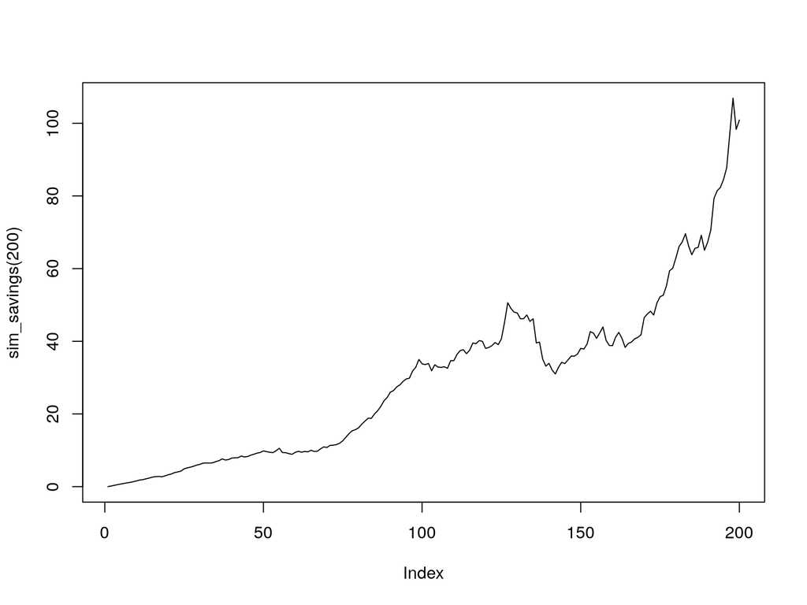

```r
#' @param n_nomths Integer, number of months to simulate.
#' @param S0 Initial balance of savings.
#' @param W Income.
#' @param c_rate Monthly contribution rate
sim_savings <- function(
  n_months = 200,
  S0       = 0,
  W_n      = 40/12,
  t_n      = .05
) {

  # Generating returns
  I <- sample(dow_monthly$r[-1], n_months, replace = TRUE)
  S <- vector("numeric", n_months)

  # First value
  S[1] <- S0

  for (i in 2:n_months)
    S[i] <- S[i - 1]*(1 + I[i]) + W_n*t_n

  return(S)

}

set.seed(444)
plot(sim_savings(200), type="l")
```

# Simulations

Running multiple simulations using the `replicate` function.

```r
# Setting the seed and defining the parameters
set.seed(1)
nsim    <- 1e4
nmonths <- 12*30

# Different runs of the simulation
ans02 <- replicate(nsim, sim_savings(nmonths, t_n = 0.025))
ans05 <- replicate(nsim, sim_savings(nmonths, t_n = 0.05))
ans10 <- replicate(nsim, sim_savings(nmonths, t_n = 0.10))
ans15 <- replicate(nsim, sim_savings(nmonths, t_n = 0.15))
```

# Analyzing the results

Stacking the last row (period) of each set of simulations using `cbind`

```r
ans <- cbind(
  "2.5%" = ans02[nmonths,],
  "5%"   = ans05[nmonths,],
  "10%"  = ans10[nmonths,],
  "15%"  = ans15[nmonths,]
  )

# We can look at a few observations with the `head` function
head(ans)
```

```
##           2.5%       5%      10%      15%
## [1,] 130.11013 311.7543 372.9619 784.5688
## [2,]  57.26163 251.6799 889.4791 993.9193
## [3,]  46.66382 269.1880 272.6636 811.2884
## [4,] 247.68940 296.4977 303.2362 637.0408
## [5,] 116.52106 224.5609 302.6881 684.8367
## [6,]  57.85189 181.4546 233.9898 511.4277
```

# Visualizing the output

```r
plot_CI <- function(x, conf_interval=.95, col="steelblue")  {

  # Computing cureves
  lvl <- (1-conf_interval)/2
  lvl <- c(lvl, .5, 1-lvl)
  dat <- t(apply(x, 2, quantile, lvl))

  # Emptyplot
  plot(NA,xlim = c(1,nrow(dat)), ylim=c(0, max(dat)),
       xlab = "Month", ylab = "Savings")

  # Drawing the confidence region
  polygon(
    c(1:nrow(dat), nrow(dat):1),
    c(dat[,1], rev(dat[,3])),
    col    = adjustcolor(col, alpha.f = .5),
    border = "transparent"
  )

  # Drawing the 50%
  lines(dat[,2], lwd=2, lty=2, col=col)
}
```

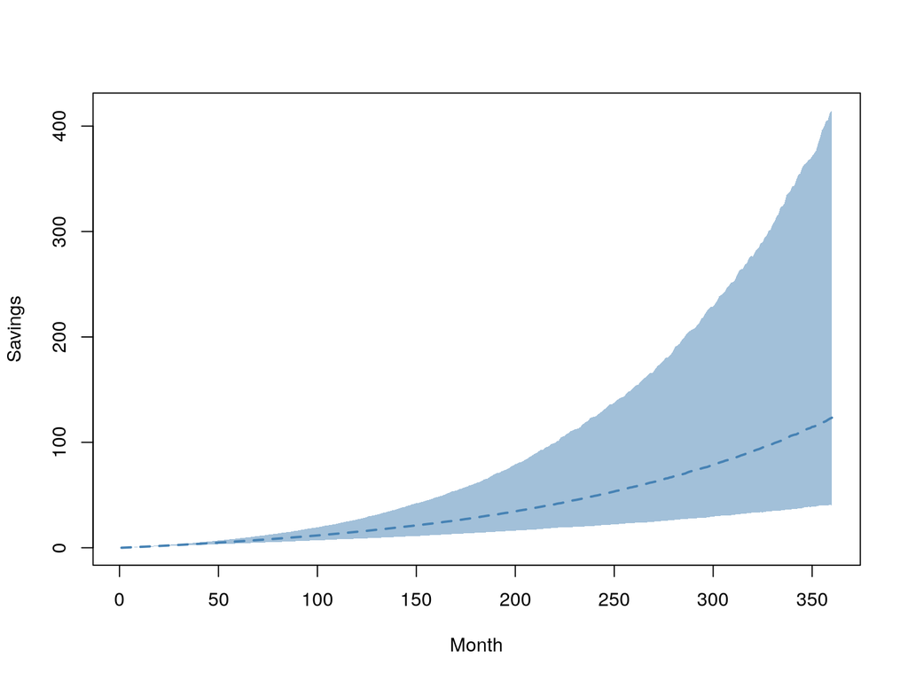

```r
plot_CI(t(ans02))
```

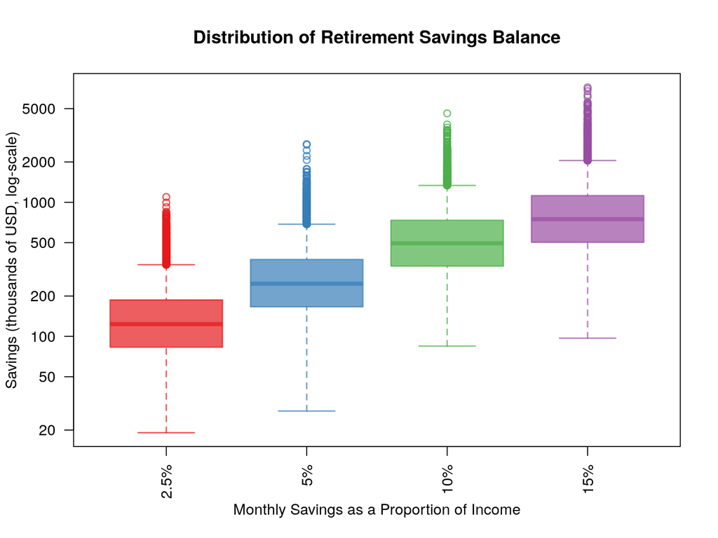

```r
# Changing the palette
palette(
  adjustcolor(RColorBrewer::brewer.pal(8, "Set1"), alpha=.7)
  )

# Using a nice-looking boxplot
boxplot(
  ans,
  main = "Distribution of Retirement Savings Balance",
  xlab = "Monthly Savings as a Proportion of Income",
  ylab = "Savings (thousands of USD, log-scale)",
  log  = "y",
  las  = 2,
  col  = 1:4,
  lwd  = 1.5,
  border = 1:4
)
```

# Thank you!

R Bootcamp day 2  
Simulation and Language Fundamentals

[figure not shown]

**website**: ggvy.cl  
**twitter**: [@gvegayon](https://twitter.com/gvegayon)  
**github**: gvegayon

[output not shown]

```
## Packages -----------------------------------------------------------------
```

[output not shown]